# Exploration of Diamond Prices

### *Author: Satakarni Bommuluri*

# Abstract

In this paper, I perform Exploratory Data Analysis (EDA) on *diamonds* dataset to understand the important features that impact the prices of diamonds in crucial manner.

# About the Dataset

The *Diamonds* dataset used in this EDA is part of the *ggplot* library. The dataset consists of a list of about 54000 diamonds. Each record comprise the price of a diamond and features of a diamond such as 4Cs: carat, cut, clarity, color, and volume related information. Below are the list of columns.

```
## Classes 'tbl_df', 'tbl' and 'data.frame':    53940 obs. of  10 variables:
##  $ carat  : num  0.23 0.21 0.23 0.29 0.31 0.24 0.24 0.26 0.22 0.23 ...
##  $ cut    : Ord.factor w/ 5 levels "Fair"<"Good"<..: 5 4 2 4 2 3 3 3 1 3 ...
##  $ color  : Ord.factor w/ 7 levels "D"<"E"<"F"<"G"<..: 2 2 2 6 7 7 6 5 2 5 ...
##  $ clarity: Ord.factor w/ 8 levels "I1"<"SI2"<"SI1"<..: 2 3 5 4 2 6 7 3 4 5 ...
##  $ depth  : num  61.5 59.8 56.9 62.4 63.3 62.8 62.3 61.9 65.1 59.4 ...
##  $ table  : num  55 61 65 58 58 57 57 55 61 61 ...
##  $ price  : int  326 326 327 334 335 336 336 337 337 338 ...
##  $ x      : num  3.95 3.89 4.05 4.2 4.34 3.94 3.95 4.07 3.87 4 ...
##  $ y      : num  3.98 3.84 4.07 4.23 4.35 3.96 3.98 4.11 3.78 4.05 ...
##  $ z      : num  2.43 2.31 2.31 2.63 2.75 2.48 2.47 2.53 2.49 2.39 ...
```

Furthermore, the columns cut, color, and clarity are factors with below ordered levels:

```
## [1] "The ascending order of quality of diamond cut levels:"
```

```
## [1] "Fair"      "Good"      "Very Good" "Premium"   "Ideal"
```

```
## [1] "The ascending order of quality of diamond color levels:"
```

```
## [1] "D" "E" "F" "G" "H" "I" "J"
```

```
## [1] "The ascending order of quality of diamond clarity levels:"
```

```
## [1] "I1"   "SI2"  "SI1"  "VS2"  "VS1"  "VVS2" "VVS1" "IF"
```

# Univariate Plots Section

We begin our analysis by exploring the distribution, any factor levels, missing values and outliers of individual variables of the dataset.

Below is the summary stats of all variables in dataset.

```
##      carat               cut        color        clarity
##  Min.   :0.2000   Fair     : 1610   D: 6775   SI1    :13065
##  1st Qu.:0.4000   Good     : 4906   E: 9797   VS2    :12258
##  Median :0.7000   Very Good:12082   F: 9542   SI2    : 9194
##  Mean   :0.7979   Premium  :13791   G:11292   VS1    : 8171
##  3rd Qu.:1.0400   Ideal    :21551   H: 8304   VVS2   : 5066
##  Max.   :5.0100                     I: 5422   VVS1   : 3655
##                                     J: 2808   (Other): 2531
##      depth           table           price             x
##  Min.   :43.00   Min.   :43.00   Min.   :  326   Min.   : 0.000
##  1st Qu.:61.00   1st Qu.:56.00   1st Qu.:  950   1st Qu.: 4.710
##  Median :61.80   Median :57.00   Median : 2401   Median : 5.700
##  Mean   :61.75   Mean   :57.46   Mean   : 3933   Mean   : 5.731
##  3rd Qu.:62.50   3rd Qu.:59.00   3rd Qu.: 5324   3rd Qu.: 6.540
##  Max.   :79.00   Max.   :95.00   Max.   :18823   Max.   :10.740
##
##        y                z
##  Min.   : 0.000   Min.   : 0.000
##  1st Qu.: 4.720   1st Qu.: 2.910
##  Median : 5.710   Median : 3.530
##  Mean   : 5.735   Mean   : 3.539
##  3rd Qu.: 6.540   3rd Qu.: 4.040
##  Max.   :58.900   Max.   :31.800
##
```

### Variable:price Analysis

From the summary stats, the values of price variable ranges from 326 to 18823. We now check the variable has any number of missing values.

```
## [1] "Total missing values:"
```

```
##
## FALSE
## 53940
```

There are no missing values for price variable. I will plot histograms to understand the distribution in price variable.

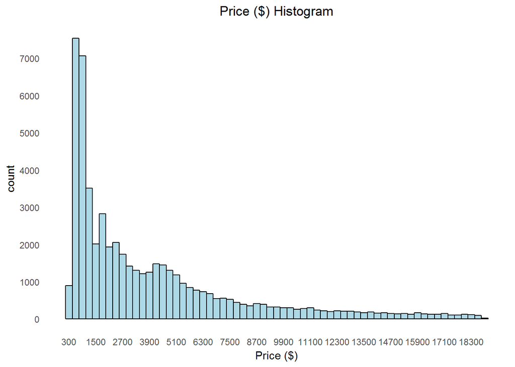

```r
table(diamonds$price < 7500)/nrow(diamonds)
```

```
##
##    FALSE     TRUE
## 0.155469 0.844531
```

Since 84% of diamonds are below $7500.00 , we will zoom-in to the prices less than $7500, and try histograms at bin widths.

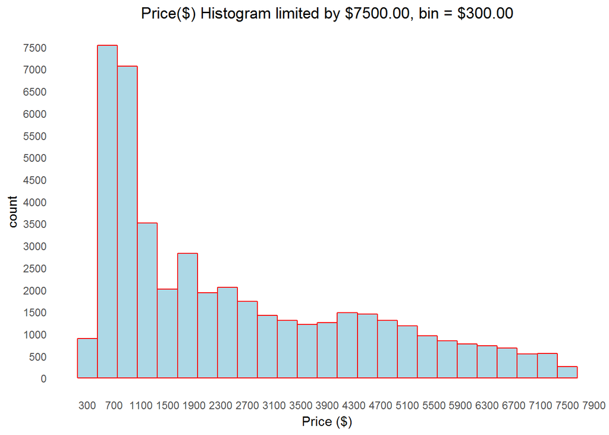

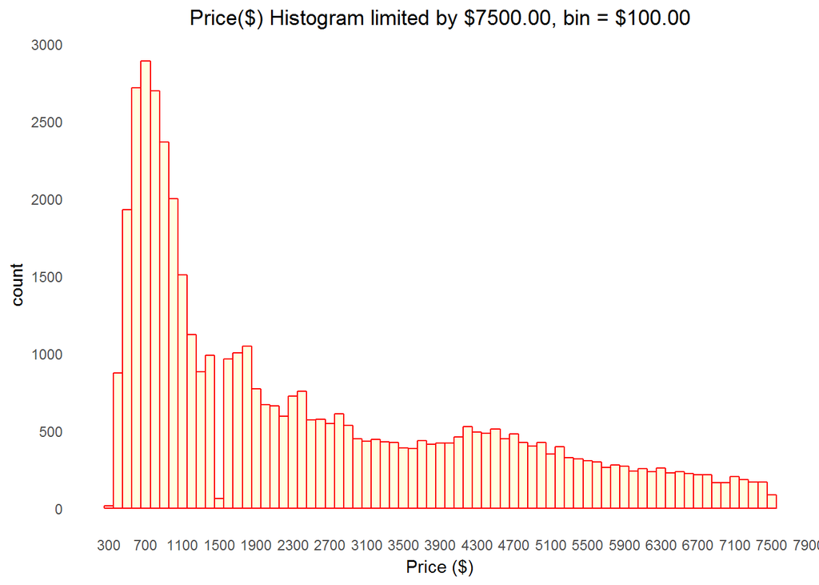

[output not shown]

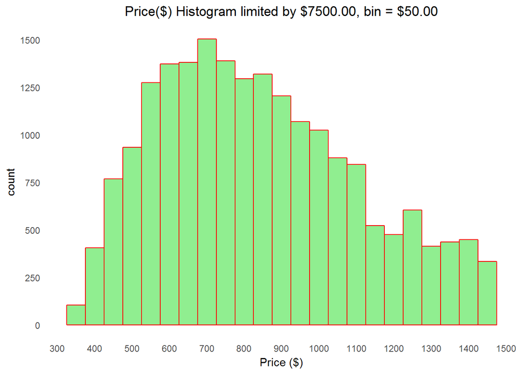

The histogram of diamonds priced under $1500 takes a uni-modal distribution.

Finally I will plot the *price* histograms on a logarithmic scale.

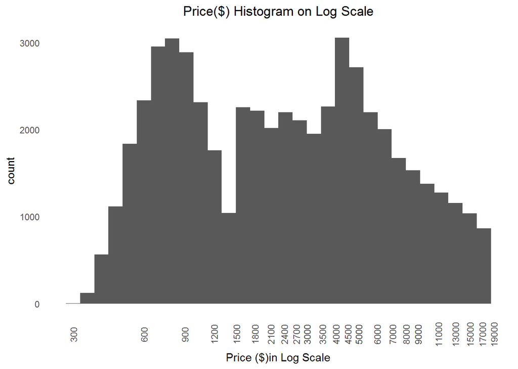

The above plot indicate two pricing segments for diamonds:

```
1. one market for below $1500 price point, and
2. another segment for above $1500 price point.
```

```r
round(table(diamonds$price < 1500)/nrow(diamonds),2) *100
```

```
##
## FALSE  TRUE
##    63    37
```

63% of market segment are for diamonds above $1500.00, as per our dataset.

### Variables:cut, clarity, and color Analysis

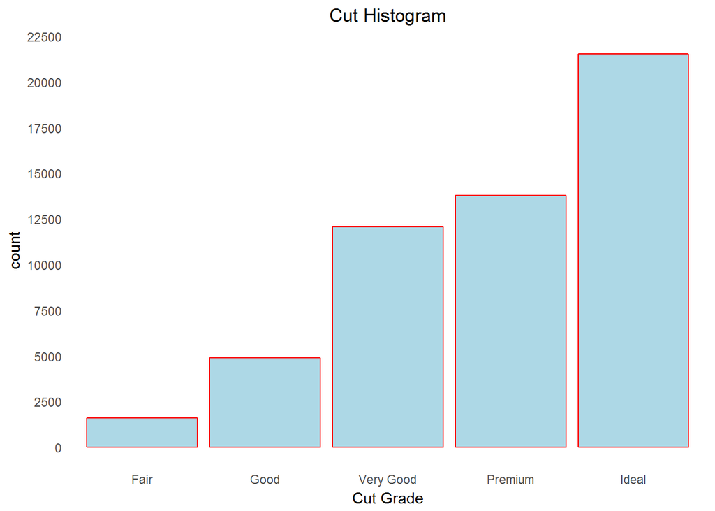

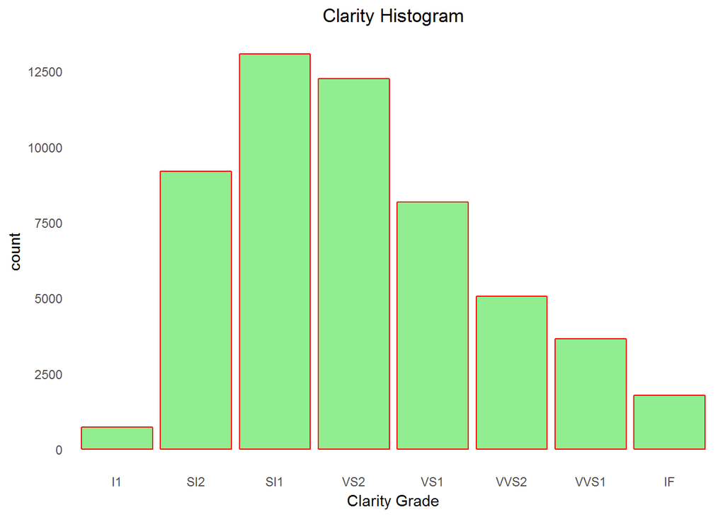

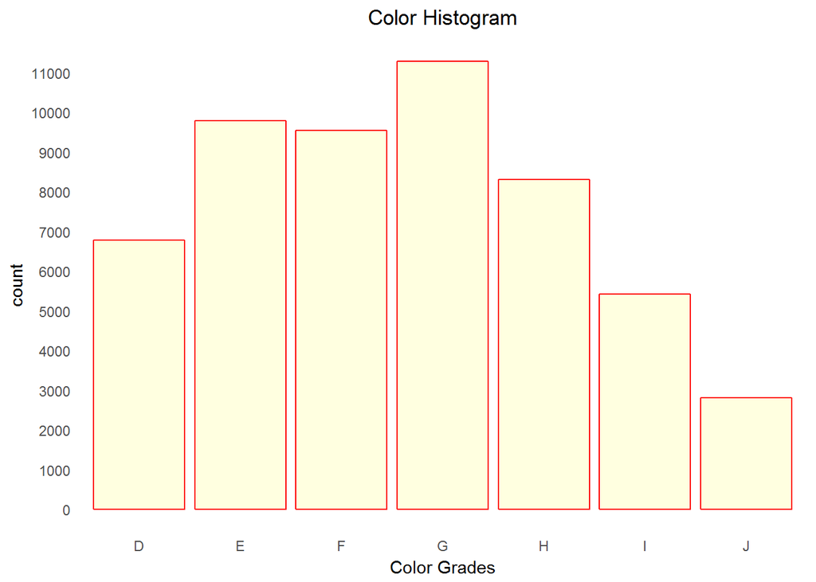

### Variable:carat (weight) Anlaysis

Following is summary stats of carats:

```
##    Min. 1st Qu.  Median    Mean 3rd Qu.    Max.
##  0.2000  0.4000  0.7000  0.7979  1.0400  5.0100
```

Given the above stats, I have chosen below bin widths and x-axis break marks.

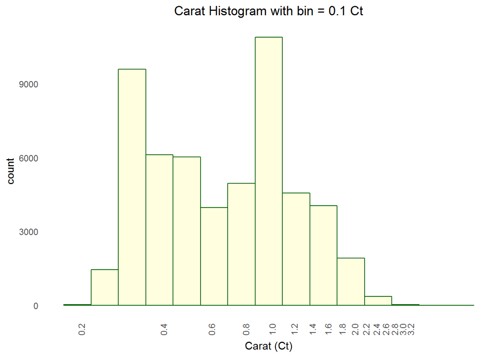

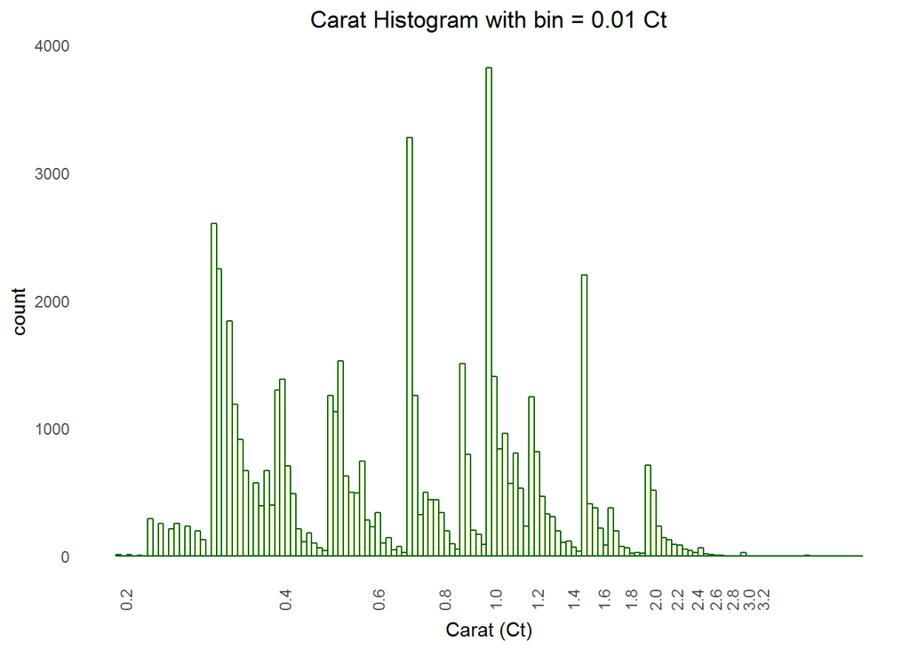

```r
table((diamonds$carat < 2.5))/nrow(diamonds)
```

```
##
##       FALSE        TRUE
## 0.002651094 0.997348906
```

The dataset contains diamonds of lower carat in large number. In specific, 99.7% diamonds weight less than 2.5 carats.

### Variable:depth, and table Analysis

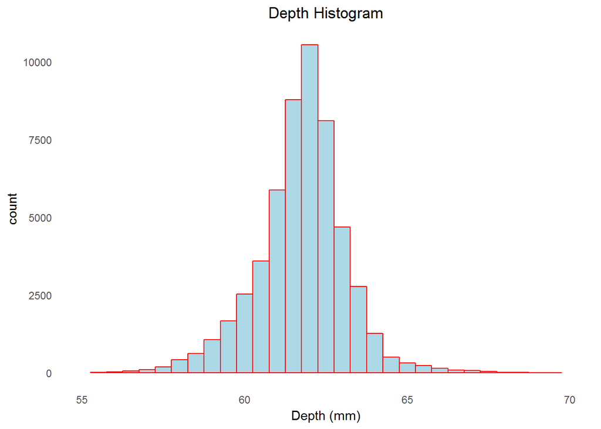

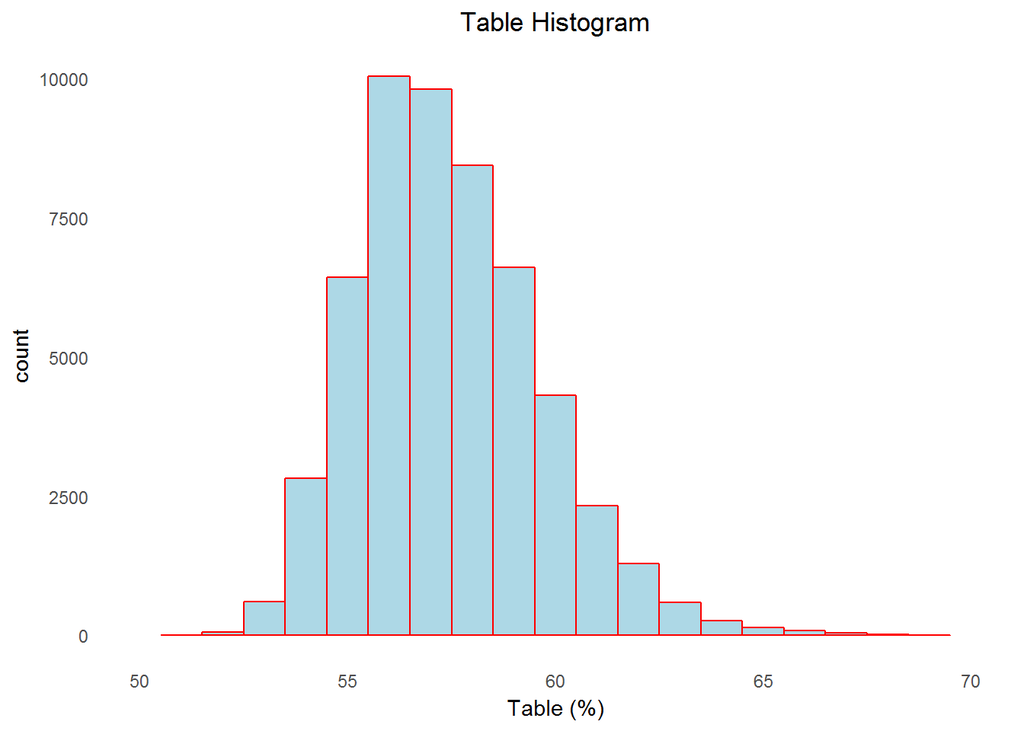

The histogram of depth and table are nearly normal distributed for chosen bin width.

### Variable:volume Analysis

We analyze the missing values for variables *x,y,* and *z*.

```
## [1] "Missing values in x:"
```

```
##
## FALSE  TRUE
## 53932     8
```

```
## [1] "Missing values in y:"
```

```
##
## FALSE  TRUE
## 53933     7
```

```
## [1] "Missing values in z:"
```

```
##
## FALSE  TRUE
## 53920    20
```

We will create a new feature in *diamond* dataset by variable name *volume*. The new variable is derived by multiplying the x,y, and z dimensions provided in the dataset (assuming diamond as a cube shape). Here is the summary stats and histogram of the *volume* variable after omitting zero values.

```
## [1] "Summary stats of volume:"
```

```
##    Min. 1st Qu.  Median    Mean 3rd Qu.    Max.
##   31.71   65.19  114.80  129.90  170.80 3841.00
```

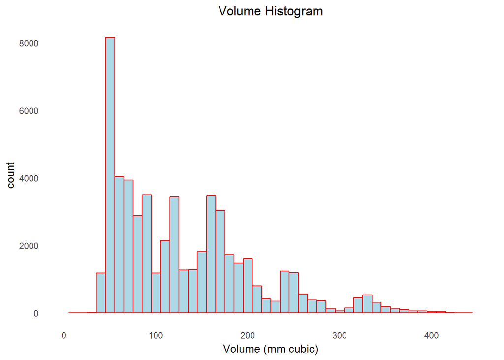

# Univariate Analysis

The univariate analysis provides information about the distribution of individual variable for a given dataset.

### Structure of dataset

The *diamond* dataset has 10 variables with almost 54000 records. Additionally it has three variables *cut*, *color*, and *clarity* that are factors with ordered levels.

### Main feature(s) of interest in dataset

In general the important features of a diamond are 4 Cs : *cut, clarity, color,* and *carat*. Specifically in our dataset, the features *cut, clarity,* and *color* are discrete and *carat* is continuous. It would be interesting to notice *price* variance with 4Cs.

### Other features of interest in the dataset

Besides 4Cs, I would like to analyze the *price* variance with *depth, table,* and *volume*.

### Any new variables from existing variables in the dataset

Yes, *volume* is created from *x,y,* and *z*.

### Commentary on unusual distributions, and data wraggling operations

Yes, the comments about distribution are mentioned below each plot in Section *univariant plot section*. The dataset is pretty tidy with few missing values for *x,y,* and *z*. During the analysis, we will ignore these missing values. During plot section, adjustments are made to zoom into certain part of data for more details.

# Bivariate Plots Section

Since there are only 11 features in dataset, I will quickly check correlation between variables by plotting scatter matrix.

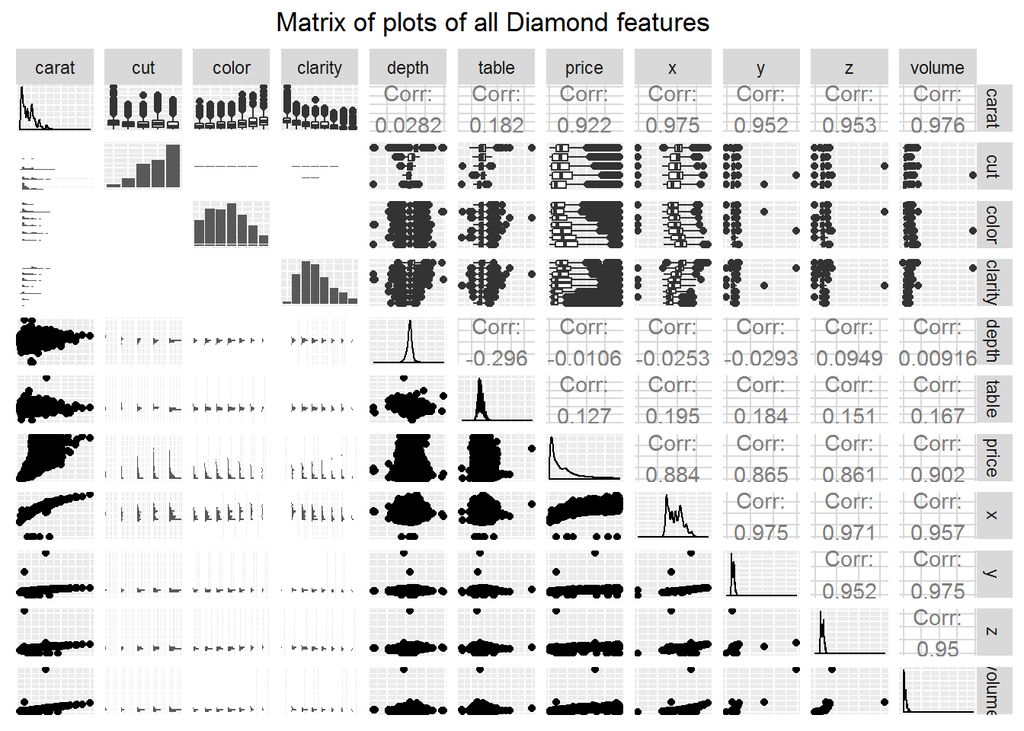

### price vs. carat

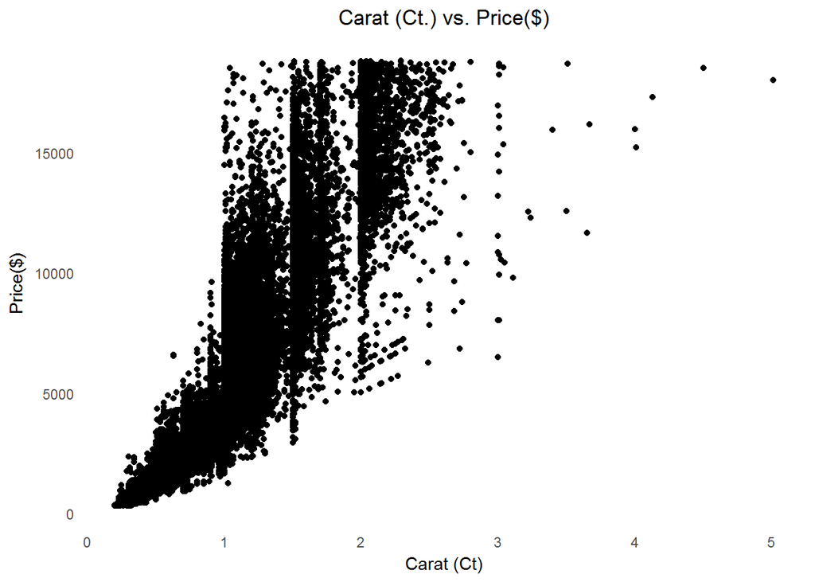

Below plot with *carat* less than 99 percentile, alpha = 1/10 and a smoothed condition line of linear model colored in red.

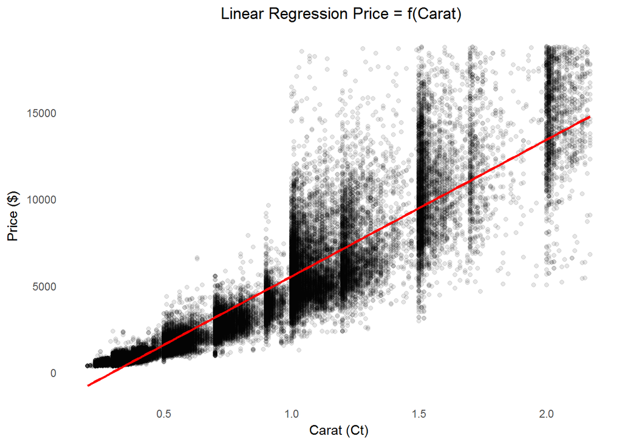

I will create a data frame that stores the aggregated mean and median prices grouped by carat. Summary stats and plot based on new data frame are as below:

```
##      carat         price_mean       price_median         n
##  Min.   :0.200   Min.   :  365.2   Min.   :  367   Min.   :   1.0
##  1st Qu.:0.880   1st Qu.: 3342.3   1st Qu.: 3284   1st Qu.:   9.0
##  Median :1.560   Median :10424.0   Median :10210   Median :  45.0
##  Mean   :1.609   Mean   : 9242.7   Mean   : 9178   Mean   : 197.6
##  3rd Qu.:2.240   3rd Qu.:14481.3   3rd Qu.:14749   3rd Qu.: 212.0
##  Max.   :5.010   Max.   :18701.0   Max.   :18701   Max.   :2604.0
```

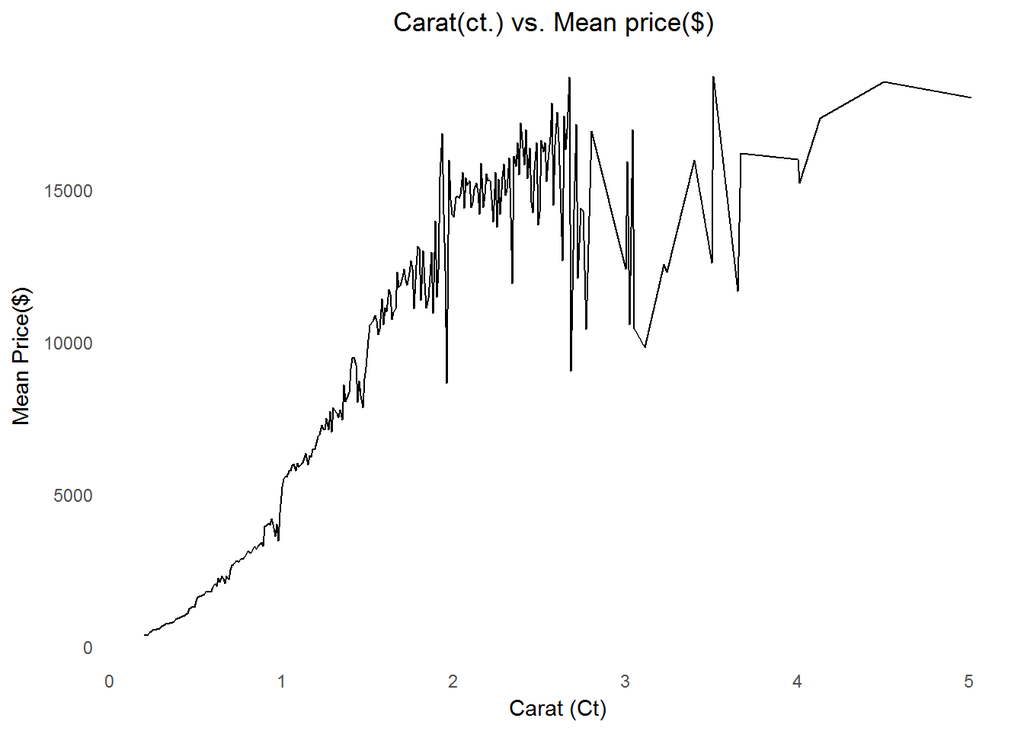

The below plot overlays the important stats, after omitting top 1% *carat* outliers :

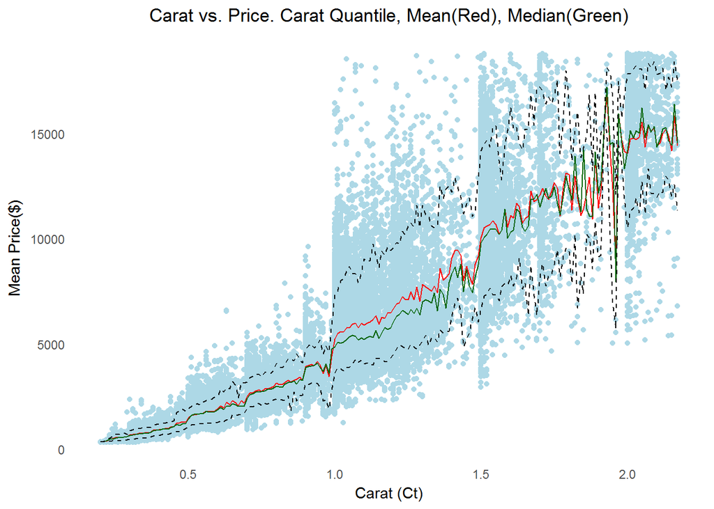

Finally, observing the correlation between *carat* vs. *price*.

```
## [1] 0.9215913
```

Hence there is strong relation between carat (weight)of the diamond and its price.

### price vs. cut, clarity, color

Unlike *carat*, the variables *cut, clarity,* and *color* are discrete variables. Hence I will use *by()* function to get the aggregates at each level, and consequently plot the box plots.

```
## diamonds$cut: Fair
##    Min. 1st Qu.  Median    Mean 3rd Qu.    Max.
##     337    2050    3282    4359    5206   18570
## --------------------------------------------------------
## diamonds$cut: Good
##    Min. 1st Qu.  Median    Mean 3rd Qu.    Max.
##     327    1145    3050    3929    5028   18790
## --------------------------------------------------------
## diamonds$cut: Very Good
##    Min. 1st Qu.  Median    Mean 3rd Qu.    Max.
##     336     912    2648    3982    5373   18820
## --------------------------------------------------------
## diamonds$cut: Premium
##    Min. 1st Qu.  Median    Mean 3rd Qu.    Max.
##     326    1046    3185    4584    6296   18820
## --------------------------------------------------------
## diamonds$cut: Ideal
##    Min. 1st Qu.  Median    Mean 3rd Qu.    Max.
##     326     878    1810    3458    4678   18810
```

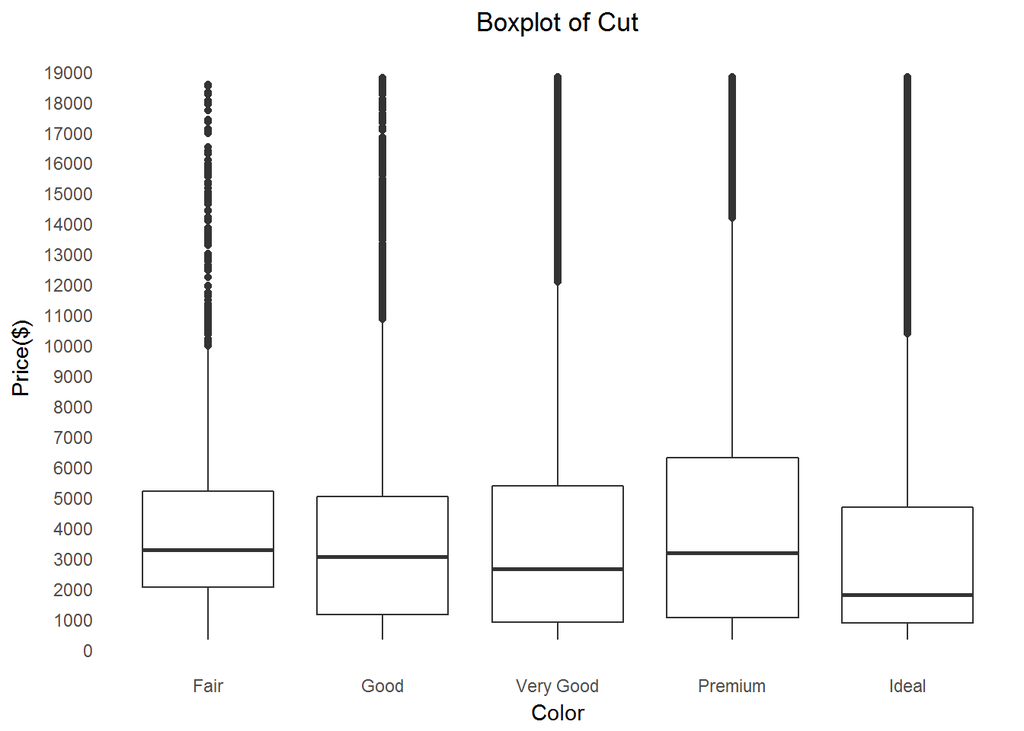

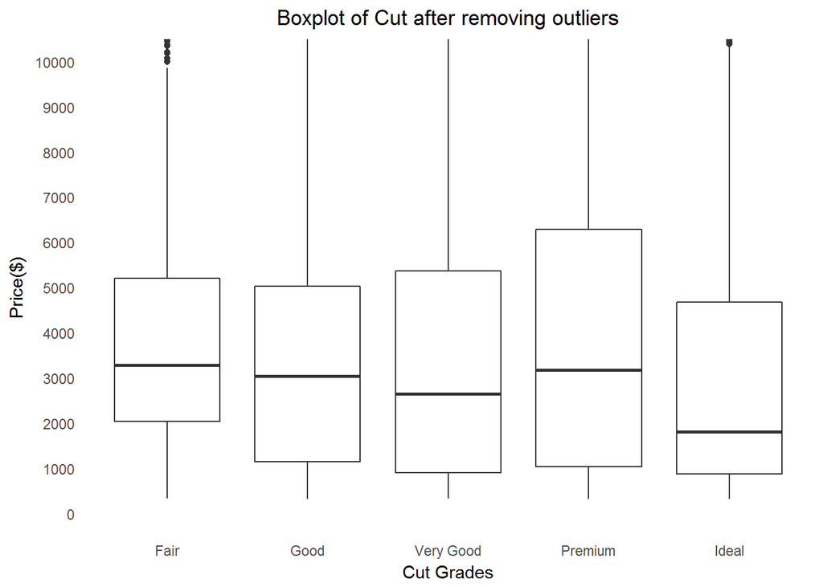

```r
ggplot(data = diamonds, aes(x = cut, y = price)) +
    geom_boxplot() +
    scale_y_continuous(breaks = seq(0,10000,1000)) +
    coord_cartesian(ylim = c(0,10000)) +
    labs(x="Cut Grades", y = "Price($)", title = "Boxplot of Cut after removing outliers") +
    theme(axis.ticks = element_blank(),
          panel.background = element_blank(),
          panel.grid = element_blank(),
          axis.text.x = element_text(),
          plot.title = element_text(hjust = 0.5))
```

The intuitive expectation would be increase in *price* with *cut* quality. However with our analysis the variance in *price* with *cut* is not giving a clear patter of ascending order. This might be due to other features influencing *price* along with *cut*. For instance high quality cut diamonds might be having lower carat in our dataset. Therefore, we will revisit *cut* variable in multivariant analysis to address these questions.

Repeating same analysis with clarity.

```
## diamonds$clarity: I1
##    Min. 1st Qu.  Median    Mean 3rd Qu.    Max.
##     345    2080    3344    3924    5161   18530
## --------------------------------------------------------
## diamonds$clarity: SI2
##    Min. 1st Qu.  Median    Mean 3rd Qu.    Max.
##     326    2264    4072    5063    5777   18800
## --------------------------------------------------------
## diamonds$clarity: SI1
##    Min. 1st Qu.  Median    Mean 3rd Qu.    Max.
##     326    1089    2822    3996    5250   18820
## --------------------------------------------------------
## diamonds$clarity: VS2
##    Min. 1st Qu.  Median    Mean 3rd Qu.    Max.
##     334     900    2054    3925    6024   18820
## --------------------------------------------------------
## diamonds$clarity: VS1
##    Min. 1st Qu.  Median    Mean 3rd Qu.    Max.
##     327     876    2005    3839    6023   18800
## --------------------------------------------------------
## diamonds$clarity: VVS2
##    Min. 1st Qu.  Median    Mean 3rd Qu.    Max.
##   336.0   794.2  1311.0  3284.0  3638.0 18770.0
## --------------------------------------------------------
## diamonds$clarity: VVS1
##    Min. 1st Qu.  Median    Mean 3rd Qu.    Max.
##     336     816    1093    2523    2379   18780
## --------------------------------------------------------
## diamonds$clarity: IF
##    Min. 1st Qu.  Median    Mean 3rd Qu.    Max.
##     369     895    1080    2865    2388   18810
```

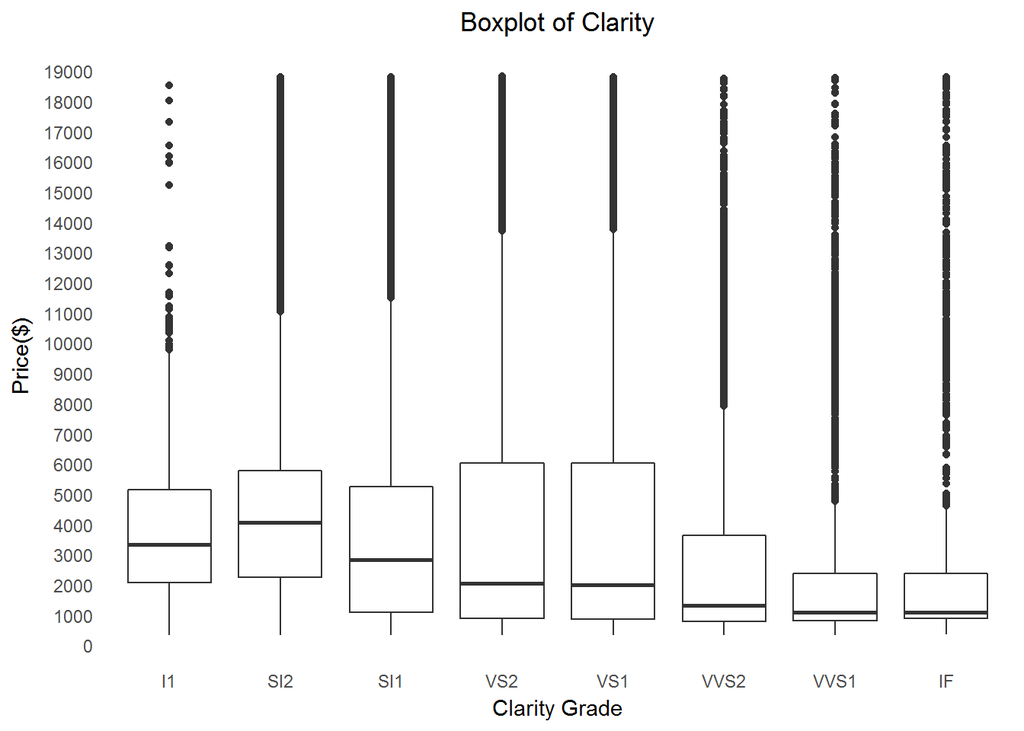

Below plot after omitting outliers i.e., prices above $7000.00

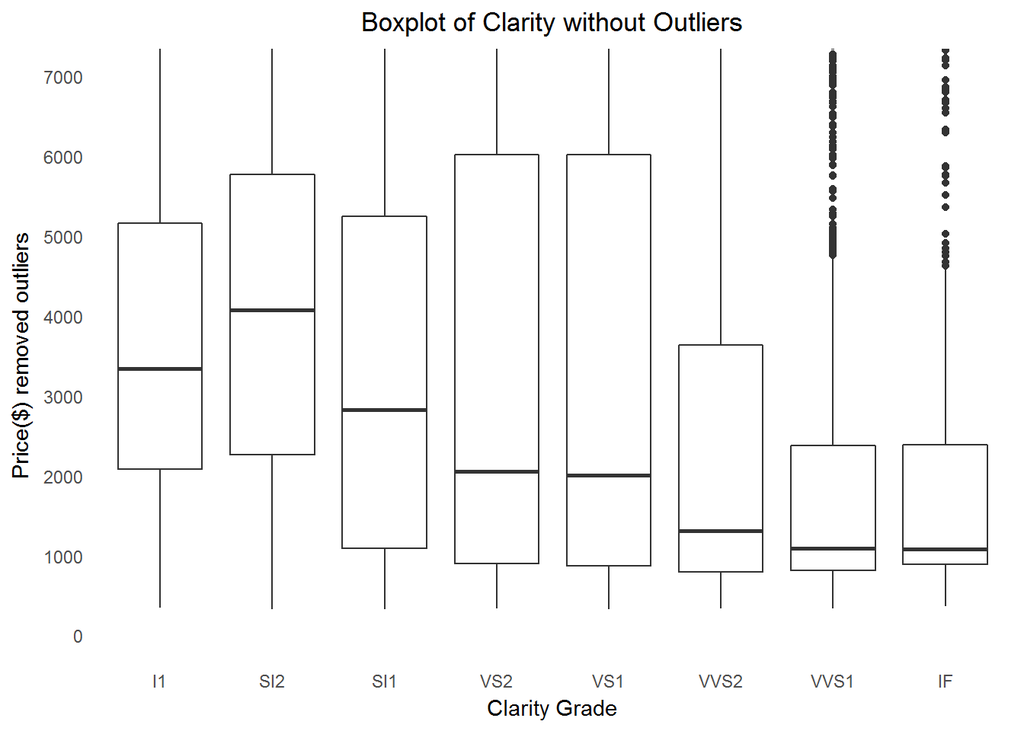

```r
ggplot(data = diamonds, aes(x = clarity, y = price)) +
    geom_boxplot() +
    scale_y_continuous(breaks = seq(0,10000,1000)) +
    coord_cartesian(ylim = c(0,7000)) +
    labs(x="Clarity Grade", y = "Price($) removed outliers", title = "Boxplot of Clarity without Outliers") +
    theme(axis.ticks = element_blank(),
          panel.background = element_blank(),
          panel.grid = element_blank(),
          axis.text.x = element_text(),
          plot.title = element_text(hjust = 0.5))
```

I have similar conclusion for *clarity* vs. *price* as I had with *cut* vs. *price*.

Now proceeding analysis with color.

```
## diamonds$color: D
##    Min. 1st Qu.  Median    Mean 3rd Qu.    Max.
##     357     911    1838    3170    4214   18690
## --------------------------------------------------------
## diamonds$color: E
##    Min. 1st Qu.  Median    Mean 3rd Qu.    Max.
##     326     882    1739    3077    4003   18730
## --------------------------------------------------------
## diamonds$color: F
##    Min. 1st Qu.  Median    Mean 3rd Qu.    Max.
##     342     982    2344    3725    4868   18790
## --------------------------------------------------------
## diamonds$color: G
##    Min. 1st Qu.  Median    Mean 3rd Qu.    Max.
##     354     931    2242    3999    6048   18820
## --------------------------------------------------------
## diamonds$color: H
##    Min. 1st Qu.  Median    Mean 3rd Qu.    Max.
##     337     984    3460    4487    5980   18800
## --------------------------------------------------------
## diamonds$color: I
##    Min. 1st Qu.  Median    Mean 3rd Qu.    Max.
##     334    1120    3730    5092    7202   18820
## --------------------------------------------------------
## diamonds$color: J
##    Min. 1st Qu.  Median    Mean 3rd Qu.    Max.
##     335    1860    4234    5324    7695   18710
```

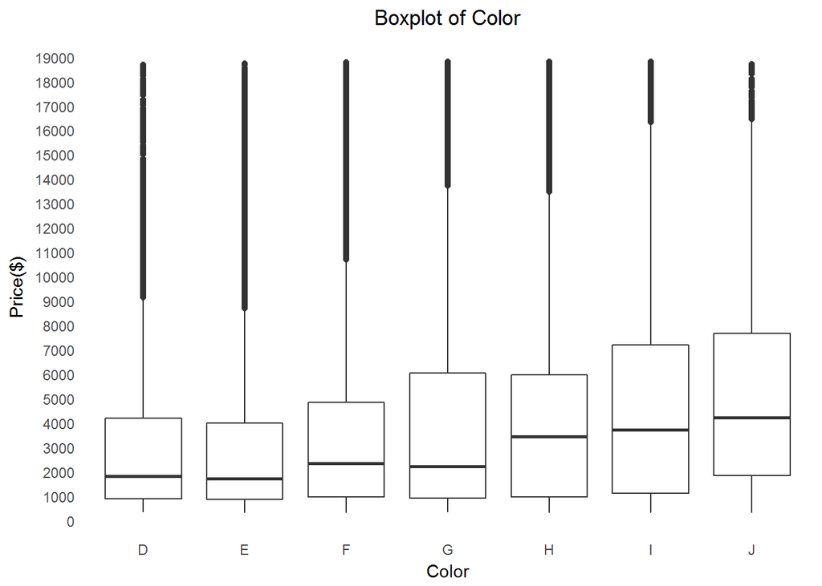

Below plot after omitting outliers i.e., prices above $8000.00

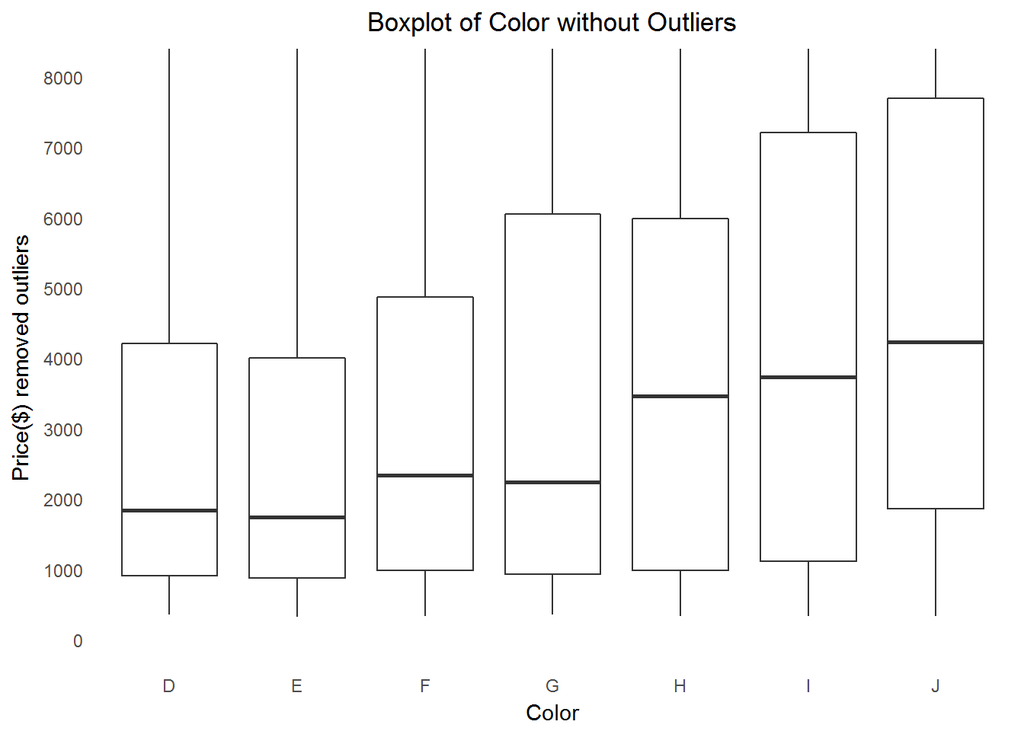

```r
ggplot(data = diamonds, aes(x = color, y = price)) +
    geom_boxplot() +
    scale_y_continuous(breaks = seq(0,10000,1000)) +
    coord_cartesian(ylim = c(0,8000)) +
    labs(x="Color", y = "Price($) removed outliers", title = "Boxplot of Color without Outliers") +
    theme(axis.ticks = element_blank(),
          panel.background = element_blank(),
          panel.grid = element_blank(),
          axis.text.x = element_text(),
          plot.title = element_text(hjust = 0.5))
```

Unlike with *cut* and *clarity*, the variable *color* is effecting the *price* of diamond by its quality.

### price vs. depth, table

As *depth* and *table* are continuous variables, I will begin with correlation test and continue my analysis with scatter plots against *price*, respectively.

The relation between *depth* and *price* is as follow:

```
## [1] -0.0106474
```

Hence it implies there is hardly any relation (positive or negative) between *depth* and *price* of diamond. If we depict a scatter plot on these variables, we should expect variance in *price* for set of constant values of *depth*.

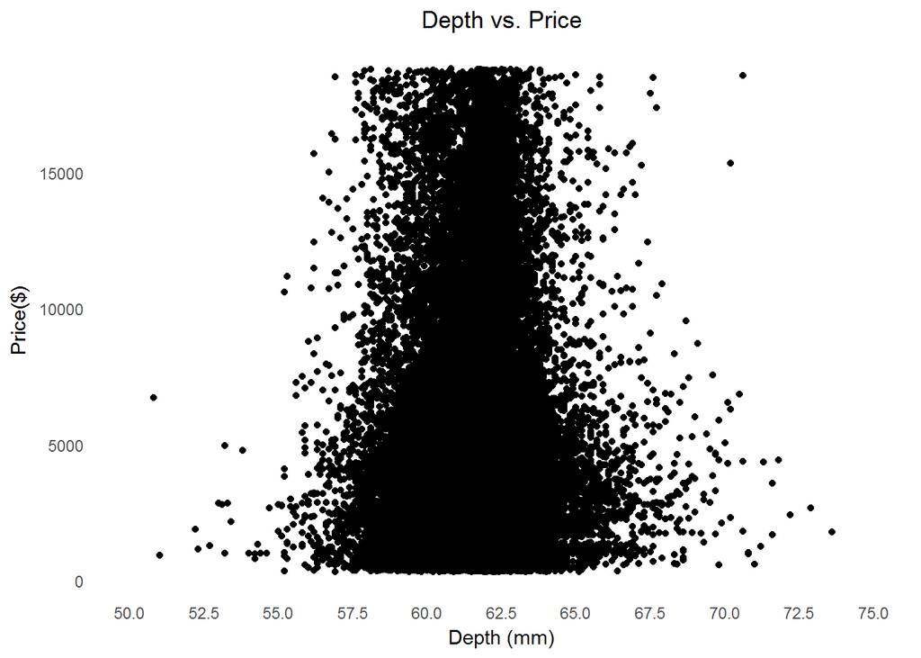

The plot tells the same story as the correlation number calculated per Pearson method.

The relation between *table* and *price* is as follow:

```
## [1] 0.1271339
```

Here it implies there is an insignificant relation between *table* and *price* of diamond. If we depict a scatter plot on these two variables, we should a very slight variance in *price* for set of constant values of *table*.

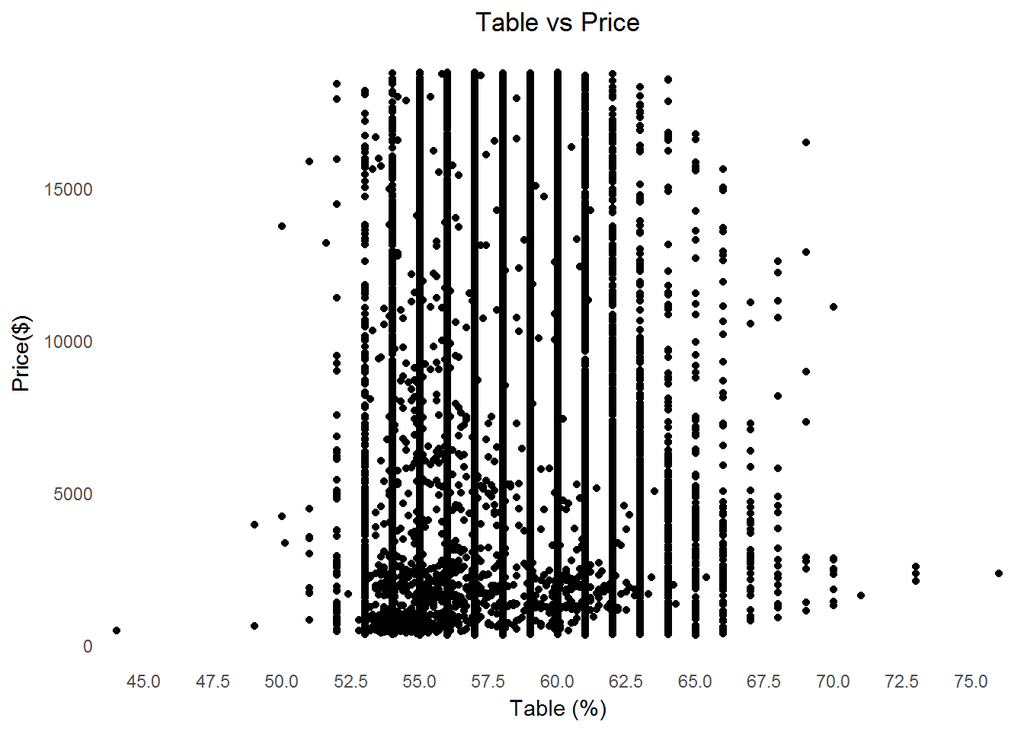

In conclusion, the variables *depth* and *table* hardly have any correlation with *price* variable. We can drop these variables from further analysis.

### price vs. volume

As *volume* is a continuous variable, I will determine its correlation with *price* followed by a scatter plot.

```
## [1] 0.9023845
```

It implies a strong positive relation between these two variables. We will expect a linear relation between *volume* and *price*.

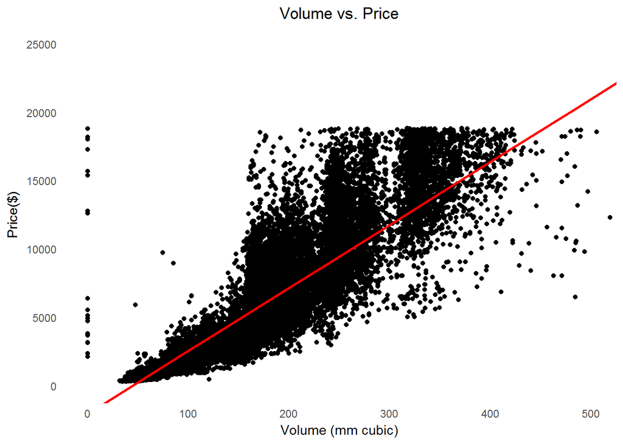

As expected from correlation coefficient, there is a near linear relation between *volume* and *price*.

# Bivariate Analysis

### Relationships observed in this part. The variance of features of interest.

Among the 4Cs, there is a strong linear relationship between *carat* and *price*. The bivariate relation of *price* vs. *cut* or *clarity* or *color* is not found strong.

### Observation of interesting relationships between the other features.

The variables *table* and *depth* don’t have strong correlation with *price*. The correlation of *volume* and *price* is linear.

### Strongest relationship found in this Section.

The variables *carat* and *volume* have strong relationship with *price*.